[OHI-Northeast](http://www.ohi-northeast.org/) | [OHI Science](http://ohi-science.org) | [Citation policy](http://ohi-science.org/citation-policy/)

# OHI-Northeast: Offshore habitat layer

Compiled on Wed Nov 20 14:53:23 2019 by afflerbach

# Summary

This script creates the offshore habitat data layer for the Habitats goal (a sub-goal of Biodiversity).

# Data

#### Fishing Effects Model

**Reference**: [NEFMC: Fishing Effects Model Report](https://s3.amazonaws.com/nefmc.org/190613_Fishing_Effects_Northeast_Report.pdf)

**Downloaded**: April 12, 2019 (shared via email)

**Description**: Spatially and temporally explicit estimate of percent habitat disturbance across the northeast region

**Time range**: 1996-2018, monthly

**Format**: Raster format

# Setup

```r
knitr::opts_chunk$set(fig.width = 6, fig.height = 4, fig.path = 'figs/',
                      echo = TRUE, message = FALSE, warning = FALSE)

source('~/github/ne-prep/src/R/common.R')

library(animation)
```

# Data Cleaning

## Load SASI data

Load and crop to our region

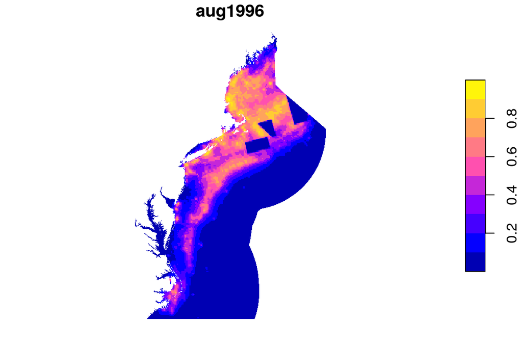

```r
sasi_raw <- read_sf(file.path(dir_anx, "_raw_data/SASI/disturbProps_allGear_20181018/disturbProps_allGear_20181018.shp"))

plot(sasi_raw[10], border = NA)
```

Clean up by cropping to our region, and averaging SASI per year.

```r
sasi2 <- sasi_raw %>%
  select(c(1, 99:267)) #gives us 2004 - 2017

for(i in 2:ncol(sasi2)){

  data <- sasi2 %>%
    select(1,i)

  ras <- fasterize::fasterize(st_collection_extract(data, "POLYGON"), ocean_ne, field = colnames(data)[2])

  writeRaster(ras, filename = paste0(dir_anx, "/hab/sasi/", colnames(data)[2], ".tif"), overwrite = T)

}
```

# Calculate layer

## Average annual fishing effect rasters

Calculate average annual rasters for impact from fishing

```r
files <- list.files(file.path(dir_anx, "hab/sasi"), full.names = T)

for(i in 2004:2017){

  f <- files[str_detect(files, as.character(i))]

  sasi_yr <- stack(f) %>%
    mean(na.rm = T)

  writeRaster(sasi_yr, filename = paste0("data/rasters/sasi_", i, ".tif"), overwrite = T)
}
```

## Animate

Create yearly gif for data visualization purposes.

[figure not shown]

```r
annual_files <- list.files("data/rasters", full.names = T)

# s <- stack(annual_files)
#
# saveGIF({
#   for(i in 1:nlayers(s)){
#       # don't forget to fix the zlimits
#       plot(s[[i]], zlim=c(0,1), axes=F, col=cols,
#            main=names(s[[i]]))
#
#   }
# }, movie.name = 'sasi.gif')
```

## Get mean fishing impacts by OHI region

Firs do this by OHI regions 1-11

```r
rgn_fe_out <- data.frame()

for(i in 2004:2017){

  f <- raster(annual_files[str_detect(annual_files, as.character(i))])

  #overlay rgns and calculate average

  rgn_fe <- raster::zonal(f, zones, fun = "mean") %>%
    as.data.frame() %>%
    mutate(year = i) %>%
    rename(rgn_id = zone,
           impact   = mean)

  rgn_fe_out <- rbind(rgn_fe_out, rgn_fe)

}
```

Doing it for the whole Northeast (region 12)

```r
ne_df_out <- data.frame()

for(i in 2004:2017){

  f <- raster(annual_files[str_detect(annual_files, as.character(i))]) %>%
    mask(ne_rgn)

  m <- cellStats(f, stat = 'mean', na.rm = TRUE)

  ne_df <- data.frame(year = i,
                      rgn_id = 12,
                      impact = m)

  ne_df_out <- rbind(ne_df_out, ne_df)

}
```

Combine

```r
rgn_fe_df <- bind_rows(rgn_fe_out, ne_df_out)
```

# Results

High impact scores should result in lower OHI scores so here we subtract impact values from 1

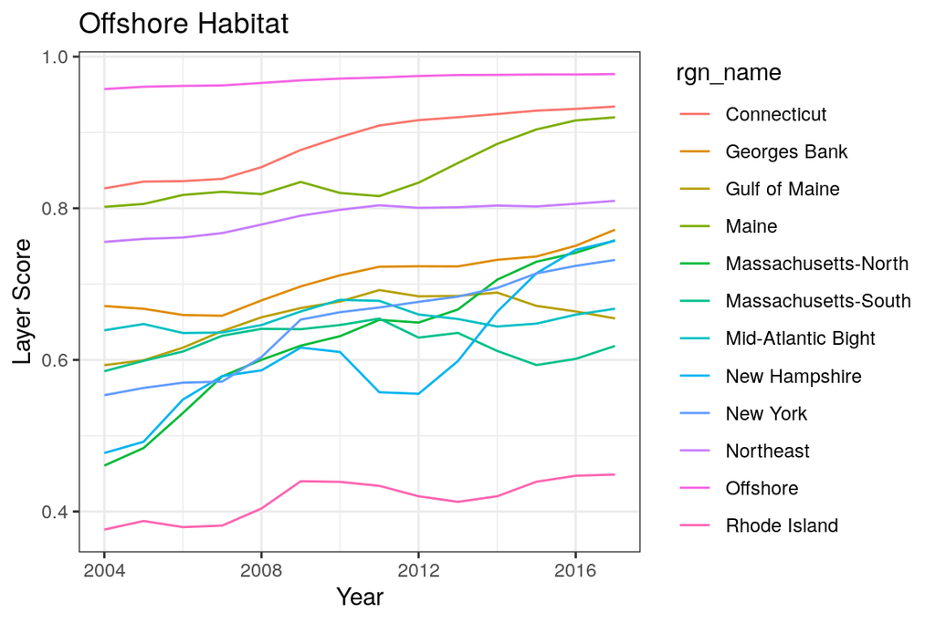

```r
rgn_impact_scores <- rgn_fe_df %>%
  mutate(score = 1-impact,
         habitat = "seabed") %>% #invert scores so high impact = low score
  left_join(rgn_data) %>%
  mutate(rgn_name = ifelse(rgn_id == 12, "Northeast", rgn_name)) %>%
  select(-area_km2, -state, -state_name, -state_abv)

ggplot(rgn_impact_scores, aes(x = year, y = score, color = rgn_name)) +
  geom_line() +
  theme_bw() +
  labs(x = "Year",
       y = "Layer Score",
       title = "Offshore Habitat")
```

# Save layer for toolbox

```r
write_csv(rgn_impact_scores %>% select(-impact), "~/github/ne-scores/region/layers/hab_fishing_effects.csv")
```

We also use the SASI data as a pressure. The higher the impact the higher the pressure so we don’t inverse scores for this layer.

```r
rgn_fe_prs <- rgn_impact_scores %>%
  select(-score) %>%
  rename(score = impact) #invert scores so high impact = low score


write_csv(rgn_fe_prs, "~/github/ne-scores/region/layers/hd_subtidal.csv")
```